# Risk Factor Analysis

## Outcome Variable

**Outcome Variable:** ever_stunted

## Predictor Variables

**Intervention Variable:** birthlen

**Adjustment Set:**

unadjusted

## Stratifying Variables

The analysis was stratified on these variable(s):

- agecat
- studyid
- country

## Data Summary

| agecat | studyid | country | birthlen | ever_stunted | n_cell | n |
| --- | --- | --- | --- | --- | --- | --- |
| 0-24 months (no birth st.) | ki0047075b-MAL-ED | BANGLADESH | >=50 cm | 0 | 23 | 211 |
| 0-24 months (no birth st.) | ki0047075b-MAL-ED | BANGLADESH | >=50 cm | 1 | 6 | 211 |
| 0-24 months (no birth st.) | ki0047075b-MAL-ED | BANGLADESH | <48 cm | 0 | 33 | 211 |
| 0-24 months (no birth st.) | ki0047075b-MAL-ED | BANGLADESH | <48 cm | 1 | 64 | 211 |
| 0-24 months (no birth st.) | ki0047075b-MAL-ED | BANGLADESH | [48-50) cm | 0 | 45 | 211 |
| 0-24 months (no birth st.) | ki0047075b-MAL-ED | BANGLADESH | [48-50) cm | 1 | 40 | 211 |
| 0-24 months (no birth st.) | ki0047075b-MAL-ED | BRAZIL | >=50 cm | 0 | 33 | 170 |
| 0-24 months (no birth st.) | ki0047075b-MAL-ED | BRAZIL | >=50 cm | 1 | 1 | 170 |
| 0-24 months (no birth st.) | ki0047075b-MAL-ED | BRAZIL | <48 cm | 0 | 38 | 170 |
| 0-24 months (no birth st.) | ki0047075b-MAL-ED | BRAZIL | <48 cm | 1 | 21 | 170 |
| 0-24 months (no birth st.) | ki0047075b-MAL-ED | BRAZIL | [48-50) cm | 0 | 73 | 170 |
| 0-24 months (no birth st.) | ki0047075b-MAL-ED | BRAZIL | [48-50) cm | 1 | 4 | 170 |
| 0-24 months (no birth st.) | ki0047075b-MAL-ED | INDIA | >=50 cm | 0 | 21 | 174 |
| 0-24 months (no birth st.) | ki0047075b-MAL-ED | INDIA | >=50 cm | 1 | 4 | 174 |
| 0-24 months (no birth st.) | ki0047075b-MAL-ED | INDIA | <48 cm | 0 | 28 | 174 |
| 0-24 months (no birth st.) | ki0047075b-MAL-ED | INDIA | <48 cm | 1 | 47 | 174 |
| 0-24 months (no birth st.) | ki0047075b-MAL-ED | INDIA | [48-50) cm | 0 | 39 | 174 |
| 0-24 months (no birth st.) | ki0047075b-MAL-ED | INDIA | [48-50) cm | 1 | 35 | 174 |
| 0-24 months (no birth st.) | ki0047075b-MAL-ED | NEPAL | >=50 cm | 0 | 37 | 155 |
| 0-24 months (no birth st.) | ki0047075b-MAL-ED | NEPAL | >=50 cm | 1 | 1 | 155 |
| 0-24 months (no birth st.) | ki0047075b-MAL-ED | NEPAL | <48 cm | 0 | 30 | 155 |
| 0-24 months (no birth st.) | ki0047075b-MAL-ED | NEPAL | <48 cm | 1 | 21 | 155 |
| 0-24 months (no birth st.) | ki0047075b-MAL-ED | NEPAL | [48-50) cm | 0 | 48 | 155 |
| 0-24 months (no birth st.) | ki0047075b-MAL-ED | NEPAL | [48-50) cm | 1 | 18 | 155 |
| 0-24 months (no birth st.) | ki0047075b-MAL-ED | PERU | >=50 cm | 0 | 21 | 255 |
| 0-24 months (no birth st.) | ki0047075b-MAL-ED | PERU | >=50 cm | 1 | 13 | 255 |
| 0-24 months (no birth st.) | ki0047075b-MAL-ED | PERU | <48 cm | 0 | 31 | 255 |
| 0-24 months (no birth st.) | ki0047075b-MAL-ED | PERU | <48 cm | 1 | 78 | 255 |
| 0-24 months (no birth st.) | ki0047075b-MAL-ED | PERU | [48-50) cm | 0 | 58 | 255 |
| 0-24 months (no birth st.) | ki0047075b-MAL-ED | PERU | [48-50) cm | 1 | 54 | 255 |

[output cut: 468 more lines]

The following strata were considered:

- agecat: 0-24 months (no birth st.), studyid: ki0047075b-MAL-ED, country: BANGLADESH
- agecat: 0-24 months (no birth st.), studyid: ki0047075b-MAL-ED, country: BRAZIL
- agecat: 0-24 months (no birth st.), studyid: ki0047075b-MAL-ED, country: INDIA
- agecat: 0-24 months (no birth st.), studyid: ki0047075b-MAL-ED, country: NEPAL
- agecat: 0-24 months (no birth st.), studyid: ki0047075b-MAL-ED, country: PERU
- agecat: 0-24 months (no birth st.), studyid: ki0047075b-MAL-ED, country: SOUTH AFRICA
- agecat: 0-24 months (no birth st.), studyid: ki0047075b-MAL-ED, country: TANZANIA, UNITED REPUBLIC OF
- agecat: 0-24 months (no birth st.), studyid: ki1000108-CMC-V-BCS-2002, country: INDIA
- agecat: 0-24 months (no birth st.), studyid: ki1000108-IRC, country: INDIA
- agecat: 0-24 months (no birth st.), studyid: ki1000109-EE, country: PAKISTAN
- agecat: 0-24 months (no birth st.), studyid: ki1000109-ResPak, country: PAKISTAN
- agecat: 0-24 months (no birth st.), studyid: ki1000304b-SAS-CompFeed, country: INDIA
- agecat: 0-24 months (no birth st.), studyid: ki1017093-NIH-Birth, country: BANGLADESH
- agecat: 0-24 months (no birth st.), studyid: ki1017093b-PROVIDE, country: BANGLADESH
- agecat: 0-24 months (no birth st.), studyid: ki1017093c-NIH-Crypto, country: BANGLADESH
- agecat: 0-24 months (no birth st.), studyid: ki1101329-Keneba, country: GAMBIA
- agecat: 0-24 months (no birth st.), studyid: ki1114097-CMIN, country: BANGLADESH
- agecat: 0-24 months (no birth st.), studyid: ki1114097-CMIN, country: BRAZIL
- agecat: 0-24 months (no birth st.), studyid: ki1114097-CMIN, country: GUINEA-BISSAU
- agecat: 0-24 months (no birth st.), studyid: ki1114097-CMIN, country: PERU
- agecat: 0-24 months (no birth st.), studyid: ki1114097-CONTENT, country: PERU
- agecat: 0-24 months (no birth st.), studyid: ki1119695-PROBIT, country: BELARUS
- agecat: 0-24 months (no birth st.), studyid: ki1126311-ZVITAMBO, country: ZIMBABWE
- agecat: 0-24 months (no birth st.), studyid: ki1135781-COHORTS, country: GUATEMALA
- agecat: 0-24 months (no birth st.), studyid: ki1135781-COHORTS, country: INDIA
- agecat: 0-24 months (no birth st.), studyid: ki1135781-COHORTS, country: PHILIPPINES
- agecat: 0-24 months (no birth st.), studyid: kiGH5241-JiVitA-3, country: BANGLADESH
- agecat: 0-24 months (no birth st.), studyid: kiGH5241-JiVitA-4, country: BANGLADESH
- agecat: 0-6 months (no birth st.), studyid: ki0047075b-MAL-ED, country: BANGLADESH
- agecat: 0-6 months (no birth st.), studyid: ki0047075b-MAL-ED, country: BRAZIL
- agecat: 0-6 months (no birth st.), studyid: ki0047075b-MAL-ED, country: INDIA
- agecat: 0-6 months (no birth st.), studyid: ki0047075b-MAL-ED, country: NEPAL
- agecat: 0-6 months (no birth st.), studyid: ki0047075b-MAL-ED, country: PERU
- agecat: 0-6 months (no birth st.), studyid: ki0047075b-MAL-ED, country: SOUTH AFRICA
- agecat: 0-6 months (no birth st.), studyid: ki0047075b-MAL-ED, country: TANZANIA, UNITED REPUBLIC OF
- agecat: 0-6 months (no birth st.), studyid: ki1000108-CMC-V-BCS-2002, country: INDIA
- agecat: 0-6 months (no birth st.), studyid: ki1000108-IRC, country: INDIA
- agecat: 0-6 months (no birth st.), studyid: ki1000109-EE, country: PAKISTAN
- agecat: 0-6 months (no birth st.), studyid: ki1000109-ResPak, country: PAKISTAN
- agecat: 0-6 months (no birth st.), studyid: ki1000304b-SAS-CompFeed, country: INDIA
- agecat: 0-6 months (no birth st.), studyid: ki1017093-NIH-Birth, country: BANGLADESH
- agecat: 0-6 months (no birth st.), studyid: ki1017093b-PROVIDE, country: BANGLADESH
- agecat: 0-6 months (no birth st.), studyid: ki1017093c-NIH-Crypto, country: BANGLADESH
- agecat: 0-6 months (no birth st.), studyid: ki1101329-Keneba, country: GAMBIA
- agecat: 0-6 months (no birth st.), studyid: ki1114097-CMIN, country: BANGLADESH
- agecat: 0-6 months (no birth st.), studyid: ki1114097-CMIN, country: BRAZIL
- agecat: 0-6 months (no birth st.), studyid: ki1114097-CMIN, country: GUINEA-BISSAU
- agecat: 0-6 months (no birth st.), studyid: ki1114097-CMIN, country: PERU
- agecat: 0-6 months (no birth st.), studyid: ki1114097-CONTENT, country: PERU
- agecat: 0-6 months (no birth st.), studyid: ki1119695-PROBIT, country: BELARUS
- agecat: 0-6 months (no birth st.), studyid: ki1126311-ZVITAMBO, country: ZIMBABWE
- agecat: 0-6 months (no birth st.), studyid: ki1135781-COHORTS, country: GUATEMALA
- agecat: 0-6 months (no birth st.), studyid: ki1135781-COHORTS, country: INDIA
- agecat: 0-6 months (no birth st.), studyid: ki1135781-COHORTS, country: PHILIPPINES
- agecat: 0-6 months (no birth st.), studyid: kiGH5241-JiVitA-3, country: BANGLADESH
- agecat: 0-6 months (no birth st.), studyid: kiGH5241-JiVitA-4, country: BANGLADESH
- agecat: 6-24 months, studyid: ki0047075b-MAL-ED, country: BANGLADESH
- agecat: 6-24 months, studyid: ki0047075b-MAL-ED, country: BRAZIL
- agecat: 6-24 months, studyid: ki0047075b-MAL-ED, country: INDIA
- agecat: 6-24 months, studyid: ki0047075b-MAL-ED, country: NEPAL
- agecat: 6-24 months, studyid: ki0047075b-MAL-ED, country: PERU
- agecat: 6-24 months, studyid: ki0047075b-MAL-ED, country: SOUTH AFRICA
- agecat: 6-24 months, studyid: ki0047075b-MAL-ED, country: TANZANIA, UNITED REPUBLIC OF
- agecat: 6-24 months, studyid: ki1000108-CMC-V-BCS-2002, country: INDIA
- agecat: 6-24 months, studyid: ki1000108-IRC, country: INDIA
- agecat: 6-24 months, studyid: ki1000109-EE, country: PAKISTAN
- agecat: 6-24 months, studyid: ki1000109-ResPak, country: PAKISTAN
- agecat: 6-24 months, studyid: ki1000304b-SAS-CompFeed, country: INDIA
- agecat: 6-24 months, studyid: ki1017093-NIH-Birth, country: BANGLADESH
- agecat: 6-24 months, studyid: ki1017093b-PROVIDE, country: BANGLADESH
- agecat: 6-24 months, studyid: ki1017093c-NIH-Crypto, country: BANGLADESH
- agecat: 6-24 months, studyid: ki1101329-Keneba, country: GAMBIA
- agecat: 6-24 months, studyid: ki1114097-CMIN, country: BRAZIL
- agecat: 6-24 months, studyid: ki1114097-CMIN, country: GUINEA-BISSAU
- agecat: 6-24 months, studyid: ki1114097-CMIN, country: PERU
- agecat: 6-24 months, studyid: ki1114097-CONTENT, country: PERU
- agecat: 6-24 months, studyid: ki1119695-PROBIT, country: BELARUS
- agecat: 6-24 months, studyid: ki1126311-ZVITAMBO, country: ZIMBABWE
- agecat: 6-24 months, studyid: ki1135781-COHORTS, country: GUATEMALA
- agecat: 6-24 months, studyid: ki1135781-COHORTS, country: INDIA
- agecat: 6-24 months, studyid: ki1135781-COHORTS, country: PHILIPPINES
- agecat: 6-24 months, studyid: kiGH5241-JiVitA-3, country: BANGLADESH
- agecat: 6-24 months, studyid: kiGH5241-JiVitA-4, country: BANGLADESH

### Dropped Strata

Some strata were dropped due to rare outcomes:

- agecat: 0-24 months (no birth st.), studyid: ki0047075b-MAL-ED, country: BRAZIL
- agecat: 0-24 months (no birth st.), studyid: ki0047075b-MAL-ED, country: INDIA
- agecat: 0-24 months (no birth st.), studyid: ki0047075b-MAL-ED, country: NEPAL
- agecat: 0-24 months (no birth st.), studyid: ki1000108-CMC-V-BCS-2002, country: INDIA
- agecat: 0-24 months (no birth st.), studyid: ki1000109-EE, country: PAKISTAN
- agecat: 0-24 months (no birth st.), studyid: ki1000109-ResPak, country: PAKISTAN
- agecat: 0-24 months (no birth st.), studyid: ki1114097-CMIN, country: BANGLADESH
- agecat: 0-24 months (no birth st.), studyid: ki1114097-CMIN, country: GUINEA-BISSAU
- agecat: 0-24 months (no birth st.), studyid: ki1114097-CMIN, country: PERU
- agecat: 0-24 months (no birth st.), studyid: ki1114097-CONTENT, country: PERU
- agecat: 0-6 months (no birth st.), studyid: ki0047075b-MAL-ED, country: BANGLADESH
- agecat: 0-6 months (no birth st.), studyid: ki0047075b-MAL-ED, country: BRAZIL
- agecat: 0-6 months (no birth st.), studyid: ki0047075b-MAL-ED, country: INDIA
- agecat: 0-6 months (no birth st.), studyid: ki0047075b-MAL-ED, country: NEPAL
- agecat: 0-6 months (no birth st.), studyid: ki0047075b-MAL-ED, country: PERU
- agecat: 0-6 months (no birth st.), studyid: ki0047075b-MAL-ED, country: TANZANIA, UNITED REPUBLIC OF
- agecat: 0-6 months (no birth st.), studyid: ki1000109-ResPak, country: PAKISTAN
- agecat: 0-6 months (no birth st.), studyid: ki1017093-NIH-Birth, country: BANGLADESH
- agecat: 0-6 months (no birth st.), studyid: ki1017093b-PROVIDE, country: BANGLADESH
- agecat: 0-6 months (no birth st.), studyid: ki1017093c-NIH-Crypto, country: BANGLADESH
- agecat: 0-6 months (no birth st.), studyid: ki1114097-CMIN, country: BANGLADESH
- agecat: 0-6 months (no birth st.), studyid: ki1114097-CMIN, country: BRAZIL
- agecat: 0-6 months (no birth st.), studyid: ki1114097-CMIN, country: GUINEA-BISSAU
- agecat: 0-6 months (no birth st.), studyid: ki1114097-CMIN, country: PERU
- agecat: 0-6 months (no birth st.), studyid: ki1114097-CONTENT, country: PERU
- agecat: 6-24 months, studyid: ki0047075b-MAL-ED, country: BRAZIL
- agecat: 6-24 months, studyid: ki0047075b-MAL-ED, country: INDIA
- agecat: 6-24 months, studyid: ki0047075b-MAL-ED, country: NEPAL
- agecat: 6-24 months, studyid: ki0047075b-MAL-ED, country: TANZANIA, UNITED REPUBLIC OF
- agecat: 6-24 months, studyid: ki1000108-CMC-V-BCS-2002, country: INDIA
- agecat: 6-24 months, studyid: ki1000109-EE, country: PAKISTAN
- agecat: 6-24 months, studyid: ki1000109-ResPak, country: PAKISTAN
- agecat: 6-24 months, studyid: ki1114097-CMIN, country: BRAZIL
- agecat: 6-24 months, studyid: ki1114097-CMIN, country: GUINEA-BISSAU
- agecat: 6-24 months, studyid: ki1114097-CMIN, country: PERU
- agecat: 6-24 months, studyid: ki1114097-CONTENT, country: PERU

## Methods Detail

We’re interested in the causal parameters $E[Y_a]$ for all values of $a \in \mathcal{A}$. These parameters represent the mean outcome if, possibly contrary to fact, we intervened to set all units to have $A=a$. Under the randomization and positivity assumptions, these are identified by the statistical parameters $\psi_a=E_W[E_{Y|A,W}(Y|A=a,W)]$. In addition, we’re interested in the mean of $Y$, $E[Y]$ under no intervention (the observed mean). We will estimate these parameters by using SuperLearner to fit the relevant likelihood factors – $E_{Y|A,W}(Y|A=a,W)$ and $p(A=a|W)$, and then updating our likelihood fit using a joint TMLE.

For unadjusted analyses ($W=\{\}$), initial likelihoods were estimated using Lrnr_glm to estimate the simple $E(Y|A)$ and Lrnr_mean to estimate $p(A)$. For adjusted analyses, a small library containing Lrnr_glmnet, Lrnr_xgboost, and Lrnr_mean was used.

Having estimated these parameters, we will then use the delta method to estimate relative risks and attributable risks relative to a prespecified baseline level of $A$.

# Results Detail

## Results Plots

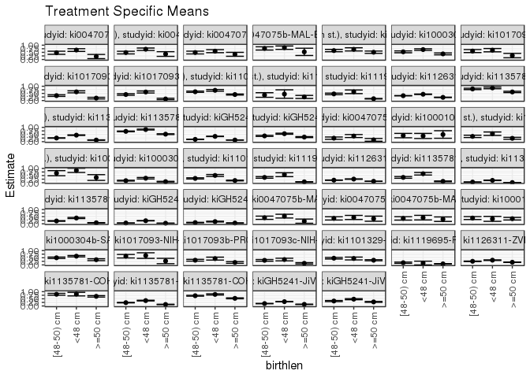

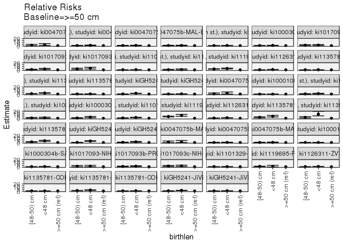

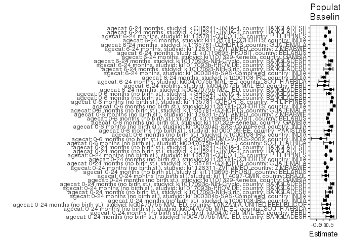

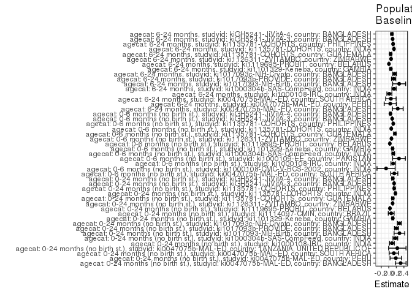

## Results Table

### Parameter: TSM

| agecat | studyid | country | intervention_level | baseline_level | estimate | ci_lower | ci_upper |
| --- | --- | --- | --- | --- | --- | --- | --- |
| 0-24 months (no birth st.) | ki0047075b-MAL-ED | BANGLADESH | >=50 cm | NA | 0.2068966 | 0.0591143 | 0.3546788 |
| 0-24 months (no birth st.) | ki0047075b-MAL-ED | BANGLADESH | <48 cm | NA | 0.6597938 | 0.5652857 | 0.7543019 |
| 0-24 months (no birth st.) | ki0047075b-MAL-ED | BANGLADESH | [48-50) cm | NA | 0.4705882 | 0.3642260 | 0.5769505 |
| 0-24 months (no birth st.) | ki0047075b-MAL-ED | PERU | >=50 cm | NA | 0.3823529 | 0.2186848 | 0.5460211 |
| 0-24 months (no birth st.) | ki0047075b-MAL-ED | PERU | <48 cm | NA | 0.7155963 | 0.6307389 | 0.8004537 |
| 0-24 months (no birth st.) | ki0047075b-MAL-ED | PERU | [48-50) cm | NA | 0.4821429 | 0.3894204 | 0.5748654 |
| 0-24 months (no birth st.) | ki0047075b-MAL-ED | SOUTH AFRICA | >=50 cm | NA | 0.3617021 | 0.2240394 | 0.4993649 |
| 0-24 months (no birth st.) | ki0047075b-MAL-ED | SOUTH AFRICA | <48 cm | NA | 0.5833333 | 0.4776781 | 0.6889886 |
| 0-24 months (no birth st.) | ki0047075b-MAL-ED | SOUTH AFRICA | [48-50) cm | NA | 0.4854369 | 0.3887105 | 0.5821633 |
| 0-24 months (no birth st.) | ki0047075b-MAL-ED | TANZANIA, UNITED REPUBLIC OF | >=50 cm | NA | 0.5333333 | 0.2796890 | 0.7869777 |
| 0-24 months (no birth st.) | ki0047075b-MAL-ED | TANZANIA, UNITED REPUBLIC OF | <48 cm | NA | 0.8250000 | 0.7067002 | 0.9432998 |
| 0-24 months (no birth st.) | ki0047075b-MAL-ED | TANZANIA, UNITED REPUBLIC OF | [48-50) cm | NA | 0.7735849 | 0.6603874 | 0.8867824 |
| 0-24 months (no birth st.) | ki1000108-IRC | INDIA | >=50 cm | NA | 0.5070423 | 0.4246927 | 0.5893918 |
| 0-24 months (no birth st.) | ki1000108-IRC | INDIA | <48 cm | NA | 0.7076923 | 0.5969626 | 0.8184220 |
| 0-24 months (no birth st.) | ki1000108-IRC | INDIA | [48-50) cm | NA | 0.6231884 | 0.5422209 | 0.7041559 |
| 0-24 months (no birth st.) | ki1000304b-SAS-CompFeed | INDIA | >=50 cm | NA | 0.3915094 | 0.3270302 | 0.4559886 |
| 0-24 months (no birth st.) | ki1000304b-SAS-CompFeed | INDIA | <48 cm | NA | 0.6923077 | 0.6344443 | 0.7501711 |
| 0-24 months (no birth st.) | ki1000304b-SAS-CompFeed | INDIA | [48-50) cm | NA | 0.5354839 | 0.4700695 | 0.6008983 |
| 0-24 months (no birth st.) | ki1017093-NIH-Birth | BANGLADESH | >=50 cm | NA | 0.2727273 | 0.1203569 | 0.4250976 |
| 0-24 months (no birth st.) | ki1017093-NIH-Birth | BANGLADESH | <48 cm | NA | 0.6515152 | 0.5362424 | 0.7667879 |
| 0-24 months (no birth st.) | ki1017093-NIH-Birth | BANGLADESH | [48-50) cm | NA | 0.5903614 | 0.4842738 | 0.6964491 |
| 0-24 months (no birth st.) | ki1017093b-PROVIDE | BANGLADESH | >=50 cm | NA | 0.1715976 | 0.1147092 | 0.2284860 |
| 0-24 months (no birth st.) | ki1017093b-PROVIDE | BANGLADESH | <48 cm | NA | 0.6098901 | 0.5389692 | 0.6808110 |
| 0-24 months (no birth st.) | ki1017093b-PROVIDE | BANGLADESH | [48-50) cm | NA | 0.3462898 | 0.2908131 | 0.4017664 |
| 0-24 months (no birth st.) | ki1017093c-NIH-Crypto | BANGLADESH | >=50 cm | NA | 0.1130952 | 0.0651675 | 0.1610230 |
| 0-24 months (no birth st.) | ki1017093c-NIH-Crypto | BANGLADESH | <48 cm | NA | 0.5989305 | 0.5286300 | 0.6692309 |
| 0-24 months (no birth st.) | ki1017093c-NIH-Crypto | BANGLADESH | [48-50) cm | NA | 0.4228188 | 0.3666874 | 0.4789502 |
| 0-24 months (no birth st.) | ki1101329-Keneba | GAMBIA | >=50 cm | NA | 0.4227749 | 0.3877339 | 0.4578159 |
| 0-24 months (no birth st.) | ki1101329-Keneba | GAMBIA | <48 cm | NA | 0.7142857 | 0.6531650 | 0.7754064 |
| 0-24 months (no birth st.) | ki1101329-Keneba | GAMBIA | [48-50) cm | NA | 0.6161616 | 0.5733053 | 0.6590179 |

[output cut: 111 more lines]

### Parameter: E(Y)

| agecat | studyid | country | intervention_level | baseline_level | estimate | ci_lower | ci_upper |
| --- | --- | --- | --- | --- | --- | --- | --- |
| 0-24 months (no birth st.) | ki0047075b-MAL-ED | BANGLADESH | NA | NA | 0.5213270 | 0.4537634 | 0.5888907 |
| 0-24 months (no birth st.) | ki0047075b-MAL-ED | PERU | NA | NA | 0.5686275 | 0.5077199 | 0.6295350 |
| 0-24 months (no birth st.) | ki0047075b-MAL-ED | SOUTH AFRICA | NA | NA | 0.4957265 | 0.4315281 | 0.5599249 |
| 0-24 months (no birth st.) | ki0047075b-MAL-ED | TANZANIA, UNITED REPUBLIC OF | NA | NA | 0.7592593 | 0.6782516 | 0.8402669 |
| 0-24 months (no birth st.) | ki1000108-IRC | INDIA | NA | NA | 0.5913043 | 0.5393557 | 0.6432530 |
| 0-24 months (no birth st.) | ki1000304b-SAS-CompFeed | INDIA | NA | NA | 0.5657407 | 0.5074689 | 0.6240126 |
| 0-24 months (no birth st.) | ki1017093-NIH-Birth | BANGLADESH | NA | NA | 0.5549451 | 0.4825447 | 0.6273454 |
| 0-24 months (no birth st.) | ki1017093b-PROVIDE | BANGLADESH | NA | NA | 0.3753943 | 0.3376725 | 0.4131162 |
| 0-24 months (no birth st.) | ki1017093c-NIH-Crypto | BANGLADESH | NA | NA | 0.3935681 | 0.3560687 | 0.4310676 |
| 0-24 months (no birth st.) | ki1101329-Keneba | GAMBIA | NA | NA | 0.5296120 | 0.5040796 | 0.5551444 |
| 0-24 months (no birth st.) | ki1114097-CMIN | BRAZIL | NA | NA | 0.3181818 | 0.2307425 | 0.4056211 |
| 0-24 months (no birth st.) | ki1119695-PROBIT | BELARUS | NA | NA | 0.1597778 | 0.1408215 | 0.1787342 |
| 0-24 months (no birth st.) | ki1126311-ZVITAMBO | ZIMBABWE | NA | NA | 0.3260417 | 0.3178171 | 0.3342662 |
| 0-24 months (no birth st.) | ki1135781-COHORTS | GUATEMALA | NA | NA | 0.7082294 | 0.6767491 | 0.7397098 |
| 0-24 months (no birth st.) | ki1135781-COHORTS | INDIA | NA | NA | 0.2867647 | 0.2751726 | 0.2983568 |
| 0-24 months (no birth st.) | ki1135781-COHORTS | PHILIPPINES | NA | NA | 0.6671324 | 0.6498678 | 0.6843969 |
| 0-24 months (no birth st.) | kiGH5241-JiVitA-3 | BANGLADESH | NA | NA | 0.2544754 | 0.2466027 | 0.2623480 |
| 0-24 months (no birth st.) | kiGH5241-JiVitA-4 | BANGLADESH | NA | NA | 0.4273585 | 0.4069266 | 0.4477904 |
| 0-6 months (no birth st.) | ki0047075b-MAL-ED | SOUTH AFRICA | NA | NA | 0.2735043 | 0.2162683 | 0.3307402 |
| 0-6 months (no birth st.) | ki1000108-CMC-V-BCS-2002 | INDIA | NA | NA | 0.4285714 | 0.3221077 | 0.5350351 |
| 0-6 months (no birth st.) | ki1000108-IRC | INDIA | NA | NA | 0.3478261 | 0.2974955 | 0.3981566 |
| 0-6 months (no birth st.) | ki1000109-EE | PAKISTAN | NA | NA | 0.6338028 | 0.5209445 | 0.7466612 |
| 0-6 months (no birth st.) | ki1000304b-SAS-CompFeed | INDIA | NA | NA | 0.1946247 | 0.1703263 | 0.2189230 |
| 0-6 months (no birth st.) | ki1101329-Keneba | GAMBIA | NA | NA | 0.2552757 | 0.2329715 | 0.2775799 |
| 0-6 months (no birth st.) | ki1119695-PROBIT | BELARUS | NA | NA | 0.0912784 | 0.0781588 | 0.1043979 |
| 0-6 months (no birth st.) | ki1126311-ZVITAMBO | ZIMBABWE | NA | NA | 0.1716896 | 0.1650721 | 0.1783072 |
| 0-6 months (no birth st.) | ki1135781-COHORTS | GUATEMALA | NA | NA | 0.2581047 | 0.2278007 | 0.2884088 |
| 0-6 months (no birth st.) | ki1135781-COHORTS | INDIA | NA | NA | 0.0790014 | 0.0720874 | 0.0859154 |
| 0-6 months (no birth st.) | ki1135781-COHORTS | PHILIPPINES | NA | NA | 0.1893119 | 0.1749594 | 0.2036645 |
| 0-6 months (no birth st.) | kiGH5241-JiVitA-3 | BANGLADESH | NA | NA | 0.1321472 | 0.1264309 | 0.1378635 |
| 0-6 months (no birth st.) | kiGH5241-JiVitA-4 | BANGLADESH | NA | NA | 0.0984277 | 0.0855770 | 0.1112784 |
| 6-24 months | ki0047075b-MAL-ED | BANGLADESH | NA | NA | 0.4230769 | 0.3453000 | 0.5008539 |
| 6-24 months | ki0047075b-MAL-ED | PERU | NA | NA | 0.3958333 | 0.3156813 | 0.4759854 |
| 6-24 months | ki0047075b-MAL-ED | SOUTH AFRICA | NA | NA | 0.3795620 | 0.2980035 | 0.4611205 |
| 6-24 months | ki1000108-IRC | INDIA | NA | NA | 0.3733333 | 0.3099915 | 0.4366752 |
| 6-24 months | ki1000304b-SAS-CompFeed | INDIA | NA | NA | 0.5006242 | 0.4555100 | 0.5457384 |
| 6-24 months | ki1017093-NIH-Birth | BANGLADESH | NA | NA | 0.5471698 | 0.4519599 | 0.6423797 |
| 6-24 months | ki1017093b-PROVIDE | BANGLADESH | NA | NA | 0.2997812 | 0.2577294 | 0.3418330 |
| 6-24 months | ki1017093c-NIH-Crypto | BANGLADESH | NA | NA | 0.2628458 | 0.2244546 | 0.3012371 |
| 6-24 months | ki1101329-Keneba | GAMBIA | NA | NA | 0.3816288 | 0.3523153 | 0.4109422 |
| 6-24 months | ki1119695-PROBIT | BELARUS | NA | NA | 0.0768510 | 0.0628857 | 0.0908164 |
| 6-24 months | ki1126311-ZVITAMBO | ZIMBABWE | NA | NA | 0.2452926 | 0.2357801 | 0.2548051 |
| 6-24 months | ki1135781-COHORTS | GUATEMALA | NA | NA | 0.7234469 | 0.6841620 | 0.7627318 |
| 6-24 months | ki1135781-COHORTS | INDIA | NA | NA | 0.2424242 | 0.2305635 | 0.2542850 |
| 6-24 months | ki1135781-COHORTS | PHILIPPINES | NA | NA | 0.6465028 | 0.6261291 | 0.6668766 |
| 6-24 months | kiGH5241-JiVitA-3 | BANGLADESH | NA | NA | 0.2160458 | 0.2066156 | 0.2254760 |
| 6-24 months | kiGH5241-JiVitA-4 | BANGLADESH | NA | NA | 0.3663989 | 0.3454886 | 0.3873091 |

### Parameter: RR

| agecat | studyid | country | intervention_level | baseline_level | estimate | ci_lower | ci_upper |
| --- | --- | --- | --- | --- | --- | --- | --- |
| 0-24 months (no birth st.) | ki0047075b-MAL-ED | BANGLADESH | >=50 cm | >=50 cm | 1.0000000 | 1.0000000 | 1.000000 |
| 0-24 months (no birth st.) | ki0047075b-MAL-ED | BANGLADESH | <48 cm | >=50 cm | 3.1890034 | 1.5391141 | 6.607530 |
| 0-24 months (no birth st.) | ki0047075b-MAL-ED | BANGLADESH | [48-50) cm | >=50 cm | 2.2745098 | 1.0752756 | 4.811227 |
| 0-24 months (no birth st.) | ki0047075b-MAL-ED | PERU | >=50 cm | >=50 cm | 1.0000000 | 1.0000000 | 1.000000 |
| 0-24 months (no birth st.) | ki0047075b-MAL-ED | PERU | <48 cm | >=50 cm | 1.8715596 | 1.2003283 | 2.918148 |
| 0-24 months (no birth st.) | ki0047075b-MAL-ED | PERU | [48-50) cm | >=50 cm | 1.2609890 | 0.7886954 | 2.016106 |
| 0-24 months (no birth st.) | ki0047075b-MAL-ED | SOUTH AFRICA | >=50 cm | >=50 cm | 1.0000000 | 1.0000000 | 1.000000 |
| 0-24 months (no birth st.) | ki0047075b-MAL-ED | SOUTH AFRICA | <48 cm | >=50 cm | 1.6127451 | 1.0580640 | 2.458213 |
| 0-24 months (no birth st.) | ki0047075b-MAL-ED | SOUTH AFRICA | [48-50) cm | >=50 cm | 1.3420902 | 0.8733902 | 2.062316 |
| 0-24 months (no birth st.) | ki0047075b-MAL-ED | TANZANIA, UNITED REPUBLIC OF | >=50 cm | >=50 cm | 1.0000000 | 1.0000000 | 1.000000 |
| 0-24 months (no birth st.) | ki0047075b-MAL-ED | TANZANIA, UNITED REPUBLIC OF | <48 cm | >=50 cm | 1.5468750 | 0.9412997 | 2.542041 |
| 0-24 months (no birth st.) | ki0047075b-MAL-ED | TANZANIA, UNITED REPUBLIC OF | [48-50) cm | >=50 cm | 1.4504717 | 0.8818823 | 2.385657 |
| 0-24 months (no birth st.) | ki1000108-IRC | INDIA | >=50 cm | >=50 cm | 1.0000000 | 1.0000000 | 1.000000 |
| 0-24 months (no birth st.) | ki1000108-IRC | INDIA | <48 cm | >=50 cm | 1.3957265 | 1.1139313 | 1.748808 |
| 0-24 months (no birth st.) | ki1000108-IRC | INDIA | [48-50) cm | >=50 cm | 1.2290660 | 0.9982707 | 1.513220 |
| 0-24 months (no birth st.) | ki1000304b-SAS-CompFeed | INDIA | >=50 cm | >=50 cm | 1.0000000 | 1.0000000 | 1.000000 |
| 0-24 months (no birth st.) | ki1000304b-SAS-CompFeed | INDIA | <48 cm | >=50 cm | 1.7683040 | 1.4860905 | 2.104111 |
| 0-24 months (no birth st.) | ki1000304b-SAS-CompFeed | INDIA | [48-50) cm | >=50 cm | 1.3677419 | 1.1668213 | 1.603260 |
| 0-24 months (no birth st.) | ki1017093-NIH-Birth | BANGLADESH | >=50 cm | >=50 cm | 1.0000000 | 1.0000000 | 1.000000 |
| 0-24 months (no birth st.) | ki1017093-NIH-Birth | BANGLADESH | <48 cm | >=50 cm | 2.3888889 | 1.3294836 | 4.292486 |
| 0-24 months (no birth st.) | ki1017093-NIH-Birth | BANGLADESH | [48-50) cm | >=50 cm | 2.1646586 | 1.2036793 | 3.892854 |
| 0-24 months (no birth st.) | ki1017093b-PROVIDE | BANGLADESH | >=50 cm | >=50 cm | 1.0000000 | 1.0000000 | 1.000000 |
| 0-24 months (no birth st.) | ki1017093b-PROVIDE | BANGLADESH | <48 cm | >=50 cm | 3.5541872 | 2.5012776 | 5.050318 |
| 0-24 months (no birth st.) | ki1017093b-PROVIDE | BANGLADESH | [48-50) cm | >=50 cm | 2.0180334 | 1.3964350 | 2.916325 |
| 0-24 months (no birth st.) | ki1017093c-NIH-Crypto | BANGLADESH | >=50 cm | >=50 cm | 1.0000000 | 1.0000000 | 1.000000 |
| 0-24 months (no birth st.) | ki1017093c-NIH-Crypto | BANGLADESH | <48 cm | >=50 cm | 5.2958064 | 3.4115897 | 8.220673 |
| 0-24 months (no birth st.) | ki1017093c-NIH-Crypto | BANGLADESH | [48-50) cm | >=50 cm | 3.7386083 | 2.3979741 | 5.828750 |
| 0-24 months (no birth st.) | ki1101329-Keneba | GAMBIA | >=50 cm | >=50 cm | 1.0000000 | 1.0000000 | 1.000000 |
| 0-24 months (no birth st.) | ki1101329-Keneba | GAMBIA | <48 cm | >=50 cm | 1.6895179 | 1.4997738 | 1.903267 |
| 0-24 months (no birth st.) | ki1101329-Keneba | GAMBIA | [48-50) cm | >=50 cm | 1.4574225 | 1.3079603 | 1.623964 |

[output cut: 111 more lines]

### Parameter: PAR

| agecat | studyid | country | intervention_level | baseline_level | estimate | ci_lower | ci_upper |
| --- | --- | --- | --- | --- | --- | --- | --- |
| 0-24 months (no birth st.) | ki0047075b-MAL-ED | BANGLADESH | >=50 cm | NA | 0.3144305 | 0.1715979 | 0.4572630 |
| 0-24 months (no birth st.) | ki0047075b-MAL-ED | PERU | >=50 cm | NA | 0.1862745 | 0.0334552 | 0.3390938 |
| 0-24 months (no birth st.) | ki0047075b-MAL-ED | SOUTH AFRICA | >=50 cm | NA | 0.1340244 | 0.0096875 | 0.2583612 |
| 0-24 months (no birth st.) | ki0047075b-MAL-ED | TANZANIA, UNITED REPUBLIC OF | >=50 cm | NA | 0.2259259 | -0.0043494 | 0.4562013 |
| 0-24 months (no birth st.) | ki1000108-IRC | INDIA | >=50 cm | NA | 0.0842621 | 0.0218305 | 0.1466937 |
| 0-24 months (no birth st.) | ki1000304b-SAS-CompFeed | INDIA | >=50 cm | NA | 0.1742313 | 0.1117890 | 0.2366736 |
| 0-24 months (no birth st.) | ki1017093-NIH-Birth | BANGLADESH | >=50 cm | NA | 0.2822178 | 0.1406576 | 0.4237780 |
| 0-24 months (no birth st.) | ki1017093b-PROVIDE | BANGLADESH | >=50 cm | NA | 0.2037967 | 0.1496313 | 0.2579621 |
| 0-24 months (no birth st.) | ki1017093c-NIH-Crypto | BANGLADESH | >=50 cm | NA | 0.2804729 | 0.2302601 | 0.3306857 |
| 0-24 months (no birth st.) | ki1101329-Keneba | GAMBIA | >=50 cm | NA | 0.1068371 | 0.0822894 | 0.1313848 |
| 0-24 months (no birth st.) | ki1114097-CMIN | BRAZIL | >=50 cm | NA | 0.0642136 | -0.0129213 | 0.1413485 |
| 0-24 months (no birth st.) | ki1119695-PROBIT | BELARUS | >=50 cm | NA | 0.0306210 | 0.0236270 | 0.0376149 |
| 0-24 months (no birth st.) | ki1126311-ZVITAMBO | ZIMBABWE | >=50 cm | NA | 0.1013934 | 0.0903144 | 0.1124725 |
| 0-24 months (no birth st.) | ki1135781-COHORTS | GUATEMALA | >=50 cm | NA | 0.1063988 | 0.0780851 | 0.1347125 |
| 0-24 months (no birth st.) | ki1135781-COHORTS | INDIA | >=50 cm | NA | 0.1752640 | 0.1587982 | 0.1917298 |
| 0-24 months (no birth st.) | ki1135781-COHORTS | PHILIPPINES | >=50 cm | NA | 0.1436603 | 0.1218089 | 0.1655117 |
| 0-24 months (no birth st.) | kiGH5241-JiVitA-3 | BANGLADESH | >=50 cm | NA | 0.1412624 | 0.1305578 | 0.1519669 |
| 0-24 months (no birth st.) | kiGH5241-JiVitA-4 | BANGLADESH | >=50 cm | NA | 0.1066212 | 0.0783105 | 0.1349319 |
| 0-6 months (no birth st.) | ki0047075b-MAL-ED | SOUTH AFRICA | >=50 cm | NA | 0.1458447 | 0.0523301 | 0.2393593 |
| 0-6 months (no birth st.) | ki1000108-CMC-V-BCS-2002 | INDIA | >=50 cm | NA | -0.0714286 | -0.3114643 | 0.1686072 |
| 0-6 months (no birth st.) | ki1000108-IRC | INDIA | >=50 cm | NA | 0.1154317 | 0.0572174 | 0.1736460 |
| 0-6 months (no birth st.) | ki1000109-EE | PAKISTAN | >=50 cm | NA | 0.2701665 | 0.1018745 | 0.4384584 |
| 0-6 months (no birth st.) | ki1000304b-SAS-CompFeed | INDIA | >=50 cm | NA | 0.1187953 | 0.0842199 | 0.1533706 |
| 0-6 months (no birth st.) | ki1101329-Keneba | GAMBIA | >=50 cm | NA | 0.1008254 | 0.0791209 | 0.1225300 |
| 0-6 months (no birth st.) | ki1119695-PROBIT | BELARUS | >=50 cm | NA | 0.0286229 | 0.0226251 | 0.0346207 |
| 0-6 months (no birth st.) | ki1126311-ZVITAMBO | ZIMBABWE | >=50 cm | NA | 0.0707678 | 0.0622543 | 0.0792812 |
| 0-6 months (no birth st.) | ki1135781-COHORTS | GUATEMALA | >=50 cm | NA | 0.1619949 | 0.1328454 | 0.1911444 |
| 0-6 months (no birth st.) | ki1135781-COHORTS | INDIA | >=50 cm | NA | 0.0656774 | 0.0575564 | 0.0737983 |
| 0-6 months (no birth st.) | ki1135781-COHORTS | PHILIPPINES | >=50 cm | NA | 0.1184527 | 0.1025357 | 0.1343697 |
| 0-6 months (no birth st.) | kiGH5241-JiVitA-3 | BANGLADESH | >=50 cm | NA | 0.0908628 | 0.0835016 | 0.0982239 |
| 0-6 months (no birth st.) | kiGH5241-JiVitA-4 | BANGLADESH | >=50 cm | NA | 0.0449715 | 0.0287156 | 0.0612273 |
| 6-24 months | ki0047075b-MAL-ED | BANGLADESH | >=50 cm | NA | 0.2378917 | 0.0958468 | 0.3799367 |
| 6-24 months | ki0047075b-MAL-ED | PERU | >=50 cm | NA | 0.0386905 | -0.1219590 | 0.1993400 |
| 6-24 months | ki0047075b-MAL-ED | SOUTH AFRICA | >=50 cm | NA | 0.0560326 | -0.0825219 | 0.1945871 |
| 6-24 months | ki1000108-IRC | INDIA | >=50 cm | NA | 0.0155352 | -0.0497737 | 0.0808441 |
| 6-24 months | ki1000304b-SAS-CompFeed | INDIA | >=50 cm | NA | 0.1384621 | 0.0818485 | 0.1950756 |
| 6-24 months | ki1017093-NIH-Birth | BANGLADESH | >=50 cm | NA | 0.2744425 | 0.1026423 | 0.4462428 |
| 6-24 months | ki1017093b-PROVIDE | BANGLADESH | >=50 cm | NA | 0.1285483 | 0.0726964 | 0.1844002 |
| 6-24 months | ki1017093c-NIH-Crypto | BANGLADESH | >=50 cm | NA | 0.1530898 | 0.1053341 | 0.2008454 |
| 6-24 months | ki1101329-Keneba | GAMBIA | >=50 cm | NA | 0.0551957 | 0.0306130 | 0.0797784 |
| 6-24 months | ki1119695-PROBIT | BELARUS | >=50 cm | NA | 0.0045550 | 0.0017845 | 0.0073256 |
| 6-24 months | ki1126311-ZVITAMBO | ZIMBABWE | >=50 cm | NA | 0.0607106 | 0.0483561 | 0.0730652 |
| 6-24 months | ki1135781-COHORTS | GUATEMALA | >=50 cm | NA | 0.0496664 | 0.0226156 | 0.0767172 |
| 6-24 months | ki1135781-COHORTS | INDIA | >=50 cm | NA | 0.1366841 | 0.1202456 | 0.1531226 |
| 6-24 months | ki1135781-COHORTS | PHILIPPINES | >=50 cm | NA | 0.1136561 | 0.0911076 | 0.1362046 |
| 6-24 months | kiGH5241-JiVitA-3 | BANGLADESH | >=50 cm | NA | 0.1014339 | 0.0875717 | 0.1152962 |
| 6-24 months | kiGH5241-JiVitA-4 | BANGLADESH | >=50 cm | NA | 0.0820852 | 0.0542438 | 0.1099265 |

### Parameter: PAF

| agecat | studyid | country | intervention_level | baseline_level | estimate | ci_lower | ci_upper |
| --- | --- | --- | --- | --- | --- | --- | --- |
| 0-24 months (no birth st.) | ki0047075b-MAL-ED | BANGLADESH | >=50 cm | NA | 0.6031348 | 0.2114978 | 0.8002517 |
| 0-24 months (no birth st.) | ki0047075b-MAL-ED | PERU | >=50 cm | NA | 0.3275862 | -0.0054384 | 0.5503053 |
| 0-24 months (no birth st.) | ki0047075b-MAL-ED | SOUTH AFRICA | >=50 cm | NA | 0.2703595 | -0.0304585 | 0.4833608 |
| 0-24 months (no birth st.) | ki0047075b-MAL-ED | TANZANIA, UNITED REPUBLIC OF | >=50 cm | NA | 0.2975610 | -0.0904717 | 0.5475164 |
| 0-24 months (no birth st.) | ki1000108-IRC | INDIA | >=50 cm | NA | 0.1425021 | 0.0289060 | 0.2428100 |
| 0-24 months (no birth st.) | ki1000304b-SAS-CompFeed | INDIA | >=50 cm | NA | 0.3079702 | 0.1994068 | 0.4018121 |
| 0-24 months (no birth st.) | ki1017093-NIH-Birth | BANGLADESH | >=50 cm | NA | 0.5085509 | 0.1708856 | 0.7086985 |
| 0-24 months (no birth st.) | ki1017093b-PROVIDE | BANGLADESH | >=50 cm | NA | 0.5428870 | 0.3796706 | 0.6631591 |
| 0-24 months (no birth st.) | ki1017093c-NIH-Crypto | BANGLADESH | >=50 cm | NA | 0.7126413 | 0.5701799 | 0.8078847 |
| 0-24 months (no birth st.) | ki1101329-Keneba | GAMBIA | >=50 cm | NA | 0.2017271 | 0.1531494 | 0.2475183 |
| 0-24 months (no birth st.) | ki1114097-CMIN | BRAZIL | >=50 cm | NA | 0.2018141 | -0.0792552 | 0.4096848 |
| 0-24 months (no birth st.) | ki1119695-PROBIT | BELARUS | >=50 cm | NA | 0.1916471 | 0.1446611 | 0.2360521 |
| 0-24 months (no birth st.) | ki1126311-ZVITAMBO | ZIMBABWE | >=50 cm | NA | 0.3109831 | 0.2764693 | 0.3438505 |
| 0-24 months (no birth st.) | ki1135781-COHORTS | GUATEMALA | >=50 cm | NA | 0.1502321 | 0.1075080 | 0.1909109 |
| 0-24 months (no birth st.) | ki1135781-COHORTS | INDIA | >=50 cm | NA | 0.6111770 | 0.5536589 | 0.6612830 |
| 0-24 months (no birth st.) | ki1135781-COHORTS | PHILIPPINES | >=50 cm | NA | 0.2153400 | 0.1808475 | 0.2483801 |
| 0-24 months (no birth st.) | kiGH5241-JiVitA-3 | BANGLADESH | >=50 cm | NA | 0.5551123 | 0.5126598 | 0.5938667 |
| 0-24 months (no birth st.) | kiGH5241-JiVitA-4 | BANGLADESH | >=50 cm | NA | 0.2494888 | 0.1801491 | 0.3129640 |
| 0-6 months (no birth st.) | ki0047075b-MAL-ED | SOUTH AFRICA | >=50 cm | NA | 0.5332447 | 0.0536809 | 0.7697811 |
| 0-6 months (no birth st.) | ki1000108-CMC-V-BCS-2002 | INDIA | >=50 cm | NA | -0.1666667 | -0.8874089 | 0.2788467 |
| 0-6 months (no birth st.) | ki1000108-IRC | INDIA | >=50 cm | NA | 0.3318662 | 0.1442262 | 0.4783636 |
| 0-6 months (no birth st.) | ki1000109-EE | PAKISTAN | >=50 cm | NA | 0.4262626 | 0.0717902 | 0.6453662 |
| 0-6 months (no birth st.) | ki1000304b-SAS-CompFeed | INDIA | >=50 cm | NA | 0.6103814 | 0.4478537 | 0.7250681 |
| 0-6 months (no birth st.) | ki1101329-Keneba | GAMBIA | >=50 cm | NA | 0.3949668 | 0.3084983 | 0.4706229 |
| 0-6 months (no birth st.) | ki1119695-PROBIT | BELARUS | >=50 cm | NA | 0.3135779 | 0.2464071 | 0.3747615 |
| 0-6 months (no birth st.) | ki1126311-ZVITAMBO | ZIMBABWE | >=50 cm | NA | 0.4121842 | 0.3625797 | 0.4579285 |
| 0-6 months (no birth st.) | ki1135781-COHORTS | GUATEMALA | >=50 cm | NA | 0.6276324 | 0.5214209 | 0.7102723 |
| 0-6 months (no birth st.) | ki1135781-COHORTS | INDIA | >=50 cm | NA | 0.8313449 | 0.7389717 | 0.8910289 |
| 0-6 months (no birth st.) | ki1135781-COHORTS | PHILIPPINES | >=50 cm | NA | 0.6257015 | 0.5460729 | 0.6913615 |
| 0-6 months (no birth st.) | kiGH5241-JiVitA-3 | BANGLADESH | >=50 cm | NA | 0.6875877 | 0.6336391 | 0.7335920 |
| 0-6 months (no birth st.) | kiGH5241-JiVitA-4 | BANGLADESH | >=50 cm | NA | 0.4568985 | 0.2707528 | 0.5955291 |
| 6-24 months | ki0047075b-MAL-ED | BANGLADESH | >=50 cm | NA | 0.5622896 | 0.0697324 | 0.7940480 |
| 6-24 months | ki0047075b-MAL-ED | PERU | >=50 cm | NA | 0.0977444 | -0.4148997 | 0.4246481 |
| 6-24 months | ki0047075b-MAL-ED | SOUTH AFRICA | >=50 cm | NA | 0.1476244 | -0.3081327 | 0.4445945 |
| 6-24 months | ki1000108-IRC | INDIA | >=50 cm | NA | 0.0416121 | -0.1503296 | 0.2015267 |
| 6-24 months | ki1000304b-SAS-CompFeed | INDIA | >=50 cm | NA | 0.2765788 | 0.1562593 | 0.3797405 |
| 6-24 months | ki1017093-NIH-Birth | BANGLADESH | >=50 cm | NA | 0.5015674 | 0.0595478 | 0.7358345 |
| 6-24 months | ki1017093b-PROVIDE | BANGLADESH | >=50 cm | NA | 0.4288071 | 0.2154596 | 0.5841370 |
| 6-24 months | ki1017093c-NIH-Crypto | BANGLADESH | >=50 cm | NA | 0.5824317 | 0.3769269 | 0.7201560 |
| 6-24 months | ki1101329-Keneba | GAMBIA | >=50 cm | NA | 0.1446318 | 0.0776715 | 0.2067309 |
| 6-24 months | ki1119695-PROBIT | BELARUS | >=50 cm | NA | 0.0592711 | 0.0229256 | 0.0942645 |
| 6-24 months | ki1126311-ZVITAMBO | ZIMBABWE | >=50 cm | NA | 0.2475029 | 0.1959143 | 0.2957818 |
| 6-24 months | ki1135781-COHORTS | GUATEMALA | >=50 cm | NA | 0.0686525 | 0.0297578 | 0.1059879 |
| 6-24 months | ki1135781-COHORTS | INDIA | >=50 cm | NA | 0.5638218 | 0.4953098 | 0.6230331 |
| 6-24 months | ki1135781-COHORTS | PHILIPPINES | >=50 cm | NA | 0.1758014 | 0.1392614 | 0.2107902 |
| 6-24 months | kiGH5241-JiVitA-3 | BANGLADESH | >=50 cm | NA | 0.4695019 | 0.4033321 | 0.5283336 |
| 6-24 months | kiGH5241-JiVitA-4 | BANGLADESH | >=50 cm | NA | 0.2240322 | 0.1446065 | 0.2960830 |